# NH3 -> HNO3로 산화시 손실되는 NH3 함량 예측 및 분석

조용일

November 17, 2019

어떤 화학공장에서 $NH_{3}$를 $HNO_{3}$로 산화시키는 공정을 가지고 있다. 이 산화공정에 미치는 중요한 변수로
$$X_1 : 공정의 작업속도 (speed)$$
$$X_2 : 냉각수의 온도 (temp)$$
를 취하여 주고, $Y$를 $NH_3$를 $HNO_3$로 바꿀 때, 손실되는 $NH_3$의 함량%(loss)로 잡아두고, Excel file로 되어 있는 자료를 $R$로 읽어 들였다.

```r
chemical = read.xlsx("./data/chemical.xlsx", 1)
head(chemical, 3)
```

```
##   id speed temp loss
## 1  1    70   20   15
## 2  2    80   27   42
## 3  3    75   25   37
```

### 회귀모형 적합하기

```r
chemical.lm = lm(loss ~ speed + temp, data=chemical)
summary(chemical.lm)
```

```
##
## Call:
## lm(formula = loss ~ speed + temp, data = chemical)
##
## Residuals:
##     Min      1Q  Median      3Q     Max
## -7.7699 -2.4093  0.2795  3.4019  4.9654
##
## Coefficients:
##             Estimate Std. Error t value Pr(>|t|)
## (Intercept) -47.6243     9.4580  -5.035 0.000704 ***
## speed         0.4216     0.2350   1.794 0.106360
## temp          1.9217     0.6977   2.754 0.022316 *
## ---
## Signif. codes:  0 '***' 0.001 '**' 0.01 '*' 0.05 '.' 0.1 ' ' 1
##
## Residual standard error: 4.465 on 9 degrees of freedom
## Multiple R-squared:  0.8539, Adjusted R-squared:  0.8214
## F-statistic:  26.3 on 2 and 9 DF,  p-value: 0.0001741
```

추정된 회귀방정식은
$$\hat{Y} = -47.624 + 0.422*speed + 1.922*temp$$
이고, 이 모형에 대한 결정계수는 $R^2 = 0.854$로서 중회귀모형이 종속변수 loss의 총변동을 $85.4%$ 정도 설경하고 있다는 것을 나타낸다. 변수 speed의 $t_0$값이
$$t_0 = \frac{\hat{\beta}_1}{\hat{\beta}_1의 표준오차} = {0.422 \over 0.235} = 1.794$$
로서, 유의확률 $p-값 = 0.106$임을 보여준다. 따라서,
$$H_0 : \beta_1 = 0$$
$$H_1 : \beta_1 \not = 0$$
의 검정에서 유의수준 $\alpha = 0.05$에서 귀무가설을 기각하지 못한다. 그러나 temp의 $t_0값 = 2.754$이고, 유의확률 $p-값 = 0.022$로서 유의수준 $\alpha = 0.05$에서 $H_0 : \beta_2 = 0$을 기각시킨다. 따라서, temp는 loss를 설명하는데 유의한 변수이다. 이와 같은 사실은 아래 추가변수그림에서 알 수 있다.

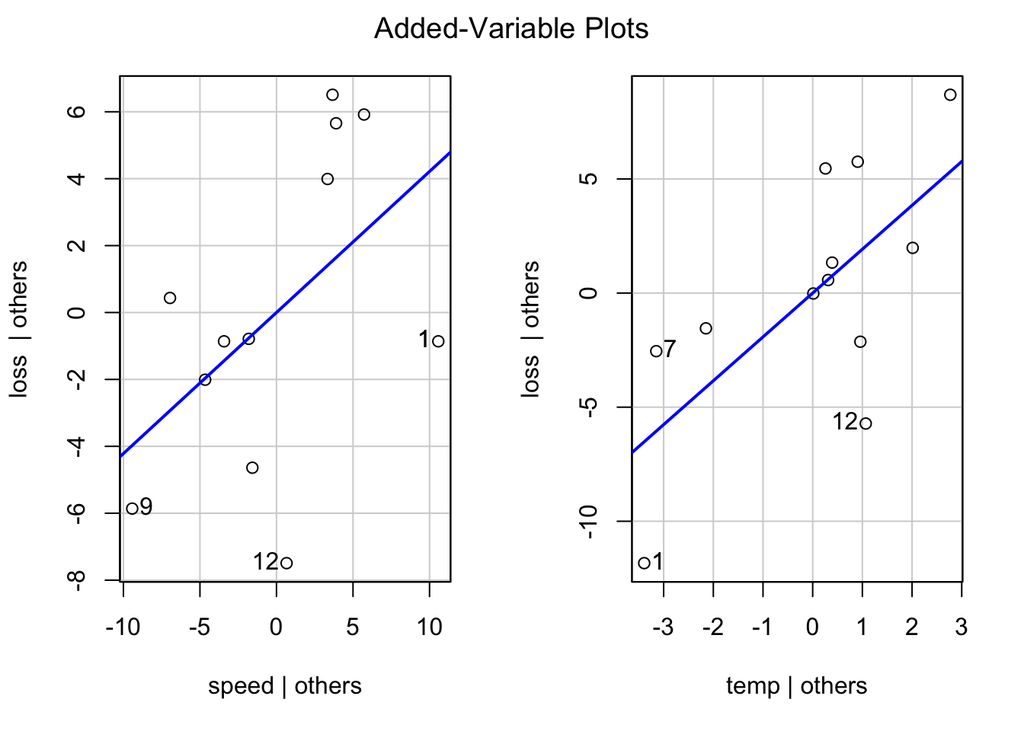

```r
avPlots(chemical.lm)
```

### 분산분석표 작성하기

```r
anova(chemical.lm)
```

```
## Analysis of Variance Table
##
## Response: loss
##           Df Sum Sq Mean Sq F value    Pr(>F)
## speed      1 897.55  897.55 45.0179 8.758e-05 ***
## temp       1 151.26  151.26  7.5867   0.02232 *
## Residuals  9 179.44   19.94
## ---
## Signif. codes:  0 '***' 0.001 '**' 0.01 '*' 0.05 '.' 0.1 ' ' 1
```

이 결과에서 다음과 같은 분산분석표를 정리할 수 있다.

[output not shown]

$F-값 = 26.3$에 대한 유의확률이 $0.00017$로 매우 작아서 중회귀모형이 매우 유의함을 알 수 있다. 또, 오차분산 $\sigma^2$의 추정치 $MSE = 19.94$임을 알 수 있다.

### 잔차산점도 그리기

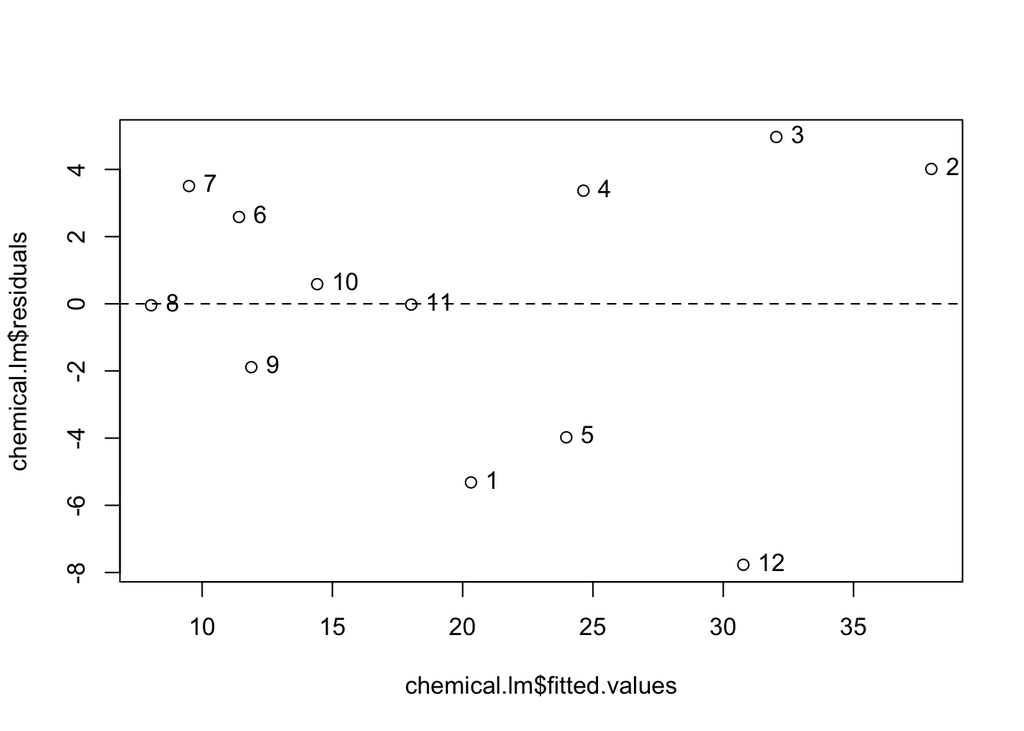

```r
plot(chemical.lm$fitted.values, chemical.lm$residuals)
abline(h=0, lty=2)
with(chemical.lm, text(fitted.values, residuals, labels = names(fitted.values), pos = 4))
```

추정값과 잔차의 산점도를 보면 12번 특이점을 제외하고는 뚜렷한 현상을 나타내고 있지 않다.